# Analysis of Streaming Transactions

Based on Data Collected by SportsTV

Gupta Srashti

Sai Venkatesh Varun Muruganandam Murali Krishnan

Fall 2025

# 1 Executive Summary

This report analyzes streaming transaction data collected by SportsTV Germany over 5 years, encompassing 98,731 total streaming events. The analysis examines viewing patterns across countries, sports, and time periods to provide insights into subscriber behavior and content preferences.

# 2 Data Overview

The analysis is based on streaming transaction data aggregated at the daily level by country and sport. The dataset spans from 2021-01-16 to 2025-10-16, covering 4 countries and 3 different sports.

Key metrics:

- **Total Streaming Events:** 98,731
- **Total Streaming Time:** 132,346 hours
- **Countries Covered:** 4
- **Sports Covered:** 3
- **Date Range:** 2021-01-16 to 2025-10-16

# 3 Growth Analysis Over Time

## 3.1 Streaming Patterns by Sport

Over the analyzed period, **Ice Hockey** emerged as the most popular sport with 38,394 streaming events, representing 38.9% of all viewing activity.

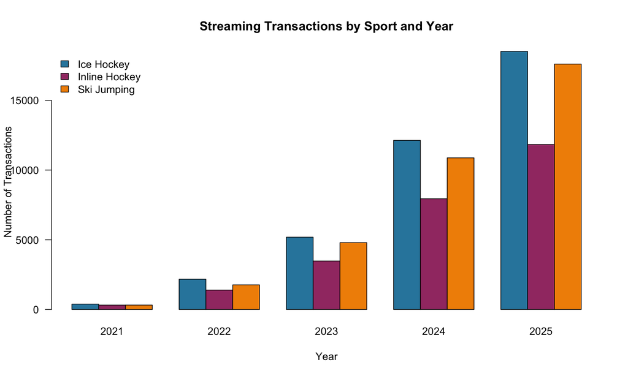

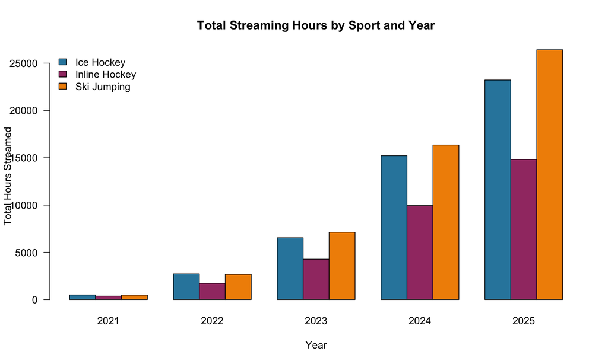

## 3.2 Analysis

The data reveals clear growth trends across all sports categories. Ice Hockey demonstrates the strongest viewership, which aligns with the German-speaking market’s traditional affinity for winter sports. The year-over-year patterns suggest seasonal variations, with certain sports showing increased activity during their respective competitive seasons.

# 4 Recent Weekly Activity

## 4.1 Streaming Events Per Week

Analysis of the most recent year (2025) shows weekly streaming patterns with peak activity in week 39, recording 1,724 streaming events.

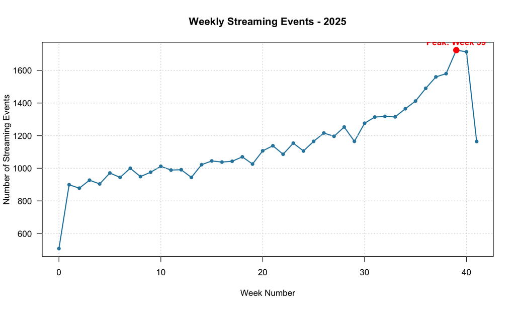

## 4.2 Observations

The weekly pattern reveals fluctuations that likely correspond to major sporting events and seasonal factors. Peak viewing weeks may align with championship games, playoffs, or holiday periods when viewers have increased leisure time.

# 5 Sport and Country Analysis

## 5.1 Average Streaming Time and Total Streams

**Österreich** leads in streaming activity with the highest number of total streams. The following table presents the breakdown of streaming activity by country and sport:

Streaming Activity by Country and Sport

| Country | Sport | Total Streams | Avg. Minutes per Stream |
| --- | --- | --- | --- |
| Österreich | Ski Jumping | 14,606 | 89.39 |
| Deutschland | Ice Hockey | 12,986 | 75.97 |
| Österreich | Ice Hockey | 12,806 | 75.56 |
| Schweiz | Ice Hockey | 12,518 | 75.20 |
| Deutschland | Ski Jumping | 12,499 | 90.96 |
| Österreich | Inline Hockey | 9,334 | 74.31 |
| Schweiz | Ski Jumping | 8,262 | 88.85 |
| Schweiz | Inline Hockey | 7,890 | 74.47 |
| Deutschland | Inline Hockey | 7,746 | 74.19 |
| Italy | Ice Hockey | 84 | 78.52 |

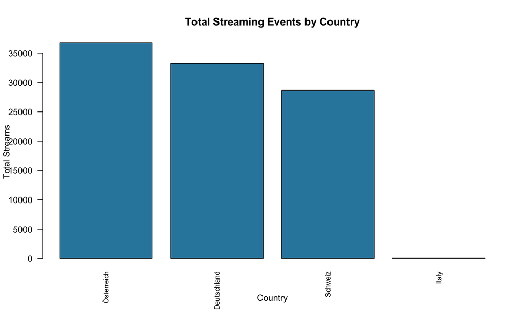

## 5.2 Key Insights

The distribution of streaming activity across countries reflects both population size and regional sport preferences. German-speaking countries show strong engagement with ice hockey content, while variations in average viewing time suggest different consumption patterns across markets.

# 6 Day of Week Patterns

## 6.1 Aggregate Analysis (Past Three Years)

Aggregating streaming time over the past three years reveals that **Tuesday** is the most popular viewing day, with 18,972 total hours streamed.

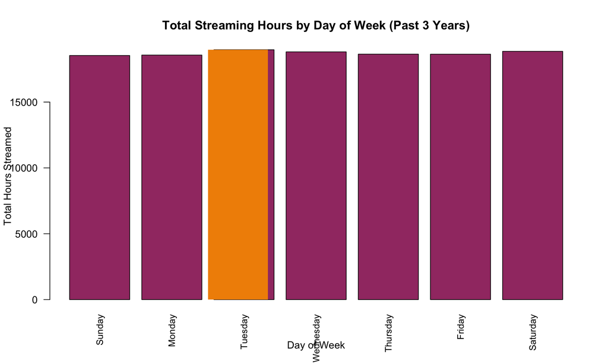

## 6.2 Day of Week by Sport

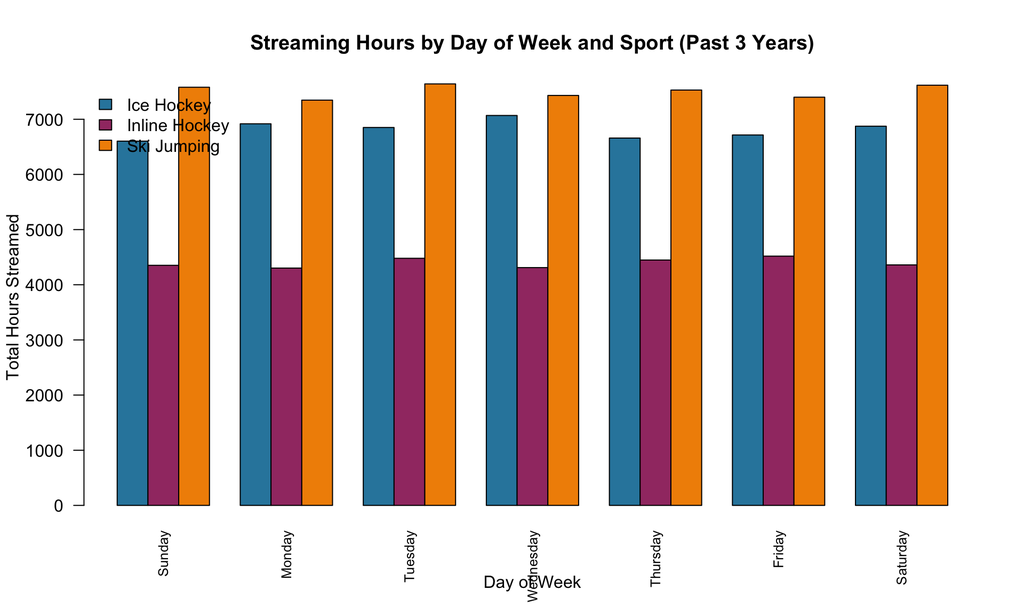

## 6.3 Day of Week by Country

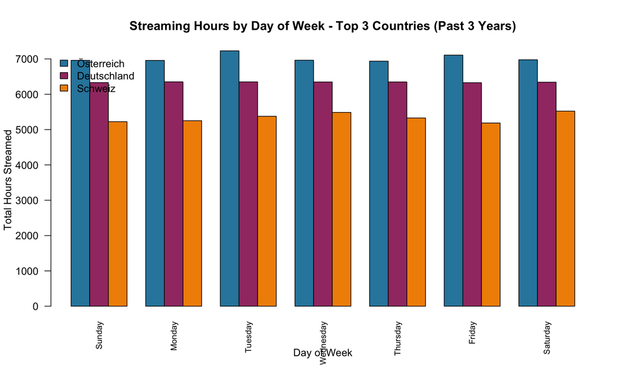

# 7 Conclusions

The analysis of SportsTV’s streaming data reveals several key findings:

1. **Content Preferences:** Ice Hockey dominates the platform with 38.9% of total streaming activity, indicating strong viewer affinity for this content.
2. **Geographic Distribution:** Österreich leads in streaming activity, suggesting either higher subscriber density or increased engagement in this market.
3. **Temporal Patterns:** Viewing activity peaks on Tuesday, with 18,972 hours of content consumed on this day over the past three years.
4. **Growth Trajectory:** The year-over-year data shows sustained engagement across all sports categories, with seasonal variations reflecting competitive calendars.

These insights can inform content acquisition strategies, marketing initiatives, and platform optimization efforts to better serve the subscriber base and drive continued growth.